# Prova 4

Nome: Filipe Augusto Parreira Almeida RA: 2320622

2023-06-06

## Questão 01 - 1,0

#### Qual o objetivo de uma análise de variância?

- A análise de variância (ANOVA) tem como principal objetivo analisar a variância de duas ou mais médias, onde, comparando com o teste de hipótese simples (em que é considerado somente duas médias/proporções), leva-se em consideração outros aspectos, como, variável resposta, o fator, níveis de tratamento, erro aleatório e delineamento. Existem dois modelos de análise de variância, o Delineamento Inteiramente Casualizado (DIC) e o Delineamento em Bloco Casualizado (DBC), no DIC considera-se somente o tratamento e o erro aleatório; já no DBC leva-se em consideração também a variável bloco, onde é visado diminuir o erro, pois caso não a considere, acarretará no aumento drástico do valor do erro.

## Questão 02 - 4,0

#### Um estudo foi elaborado para comparar o peso de vigas produzidas por 6 maquinas diferentes, sendo que quanto mais leve, melhores são as vigas. Para isso, 5 vigas de cada maquina foram testadas (dados1.csv). Faça uma análise de variância completa.

##### Verificando os itens da base de dados:

```r
dadosEx2 = read.csv("dados1.csv")
head(dadosEx2)
```

|  | maquina | peso |
| --- | --- | --- |
| 1 | a | 57.02079 |
| 2 | b | 72.94825 |
| 3 | c | 51.73240 |
| 4 | d | 49.43563 |
| 5 | e | 76.39193 |
| 6 | f | 81.56675 |

##### Análise gráfica dos dados:

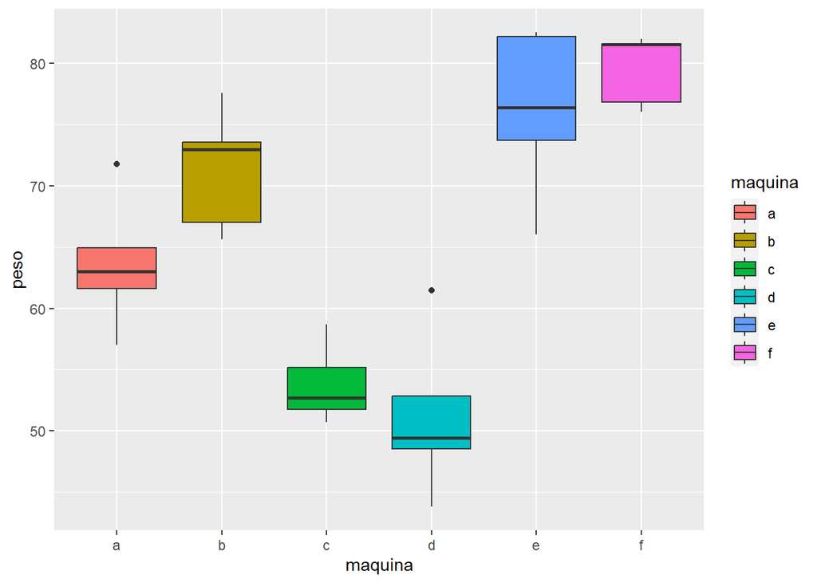

```r
library(ggplot2)
ggplot(dadosEx2, aes(maquina, peso, fill = maquina)) + geom_boxplot()
```

- Analisando o gráfico é possível perceber que as máquinas **C** e **D**, são as que produzem as vigas mais **leves**, comparadas com as outras máquinas, porém não se pode tirar nenhuma conclusão com esta análise.

##### Realizando a análise de variância utilizando o modelo DIC:

```r
library(easyanova)
modeloEx02 = ea1(dadosEx2, design = 1)
```

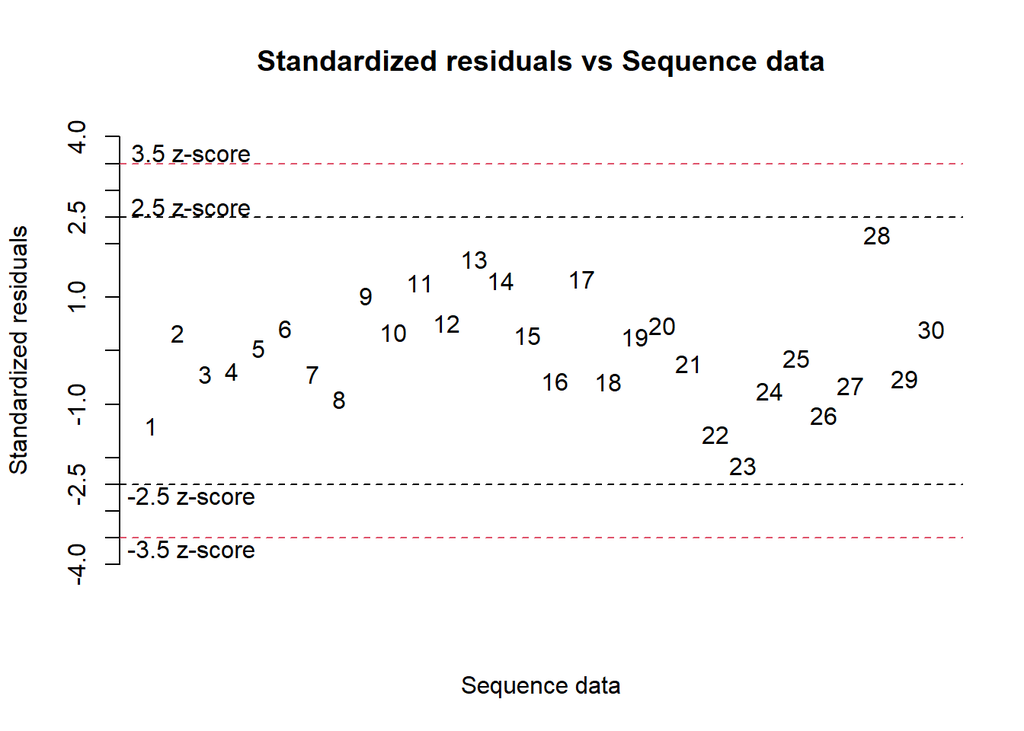

```r
modeloEx02$`Analysis of variance`
```

|  | df | type I SS | mean square | F value | p>F |
| --- | --- | --- | --- | --- | --- |
| treatments | 5 | 3449.3293 | 689.8659 | 25.601 | <0.001 |
| Residuals | 24 | 646.7232 | 26.9468 | - | - |

- O P-valor assume o valor **menor** que 0.05 (5%), portanto, dado as hipoteses padrões da análise de variância onde:
- H0 : Não existe efeito de tratamento
- H1 : Ao menos um tratamento tem efeito
- Podemos então, dado o P-valor, **desconsiderar** a hipótese nula (**H0**), sendo assim, é **válido** seguir com a análise. Através da tabela acima é possível analizar também o valor F, que vale 25.601, portanto, temos que F > 1, logo, o efeito tratamento é maior (em 25x) que o não controlado (Residuos).

##### Analisando as médias:

```r
modeloEx02$Means
```

| treatment | mean | standard.error | tukey | snk | duncan | t | scott_knott |
| --- | --- | --- | --- | --- | --- | --- | --- |
| f | 79.5973 | 2.3215 | a | a | a | a | a |
| e | 76.1673 | 2.3215 | a | ab | ab | ab | a |
| b | 71.3520 | 2.3215 | ab | b | b | b | a |
| a | 63.6562 | 2.3215 | bc | c | c | c | b |
| c | 53.8078 | 2.3215 | cd | d | d | d | c |
| d | 51.2072 | 2.3215 | d | d | d | d | c |

- **Conclusão**: Dado o teste de Tukey, pode-se concluir que tanto a máquina **C** quanto a máquina **D** são ótimas máquinas, produzindo vigas mais leves, portanto, é necessário analisar outros critérios entre as duas, para decidir qual escolher.

## Questão 03 - 5,0

#### Em um experimento, 4 tipos de estruturas de construção de pontes foram testadas, sendo elas suspensa, cantiléver, estaiada e treliça. O objetivo do experimento foi verificar quais das estruturas possuem maior resistência, ou seja, quanto mais resistente, melhor. Como o espaço para a construção das mesmas não era homogêneo, os terrenos foram divididos em 4 tipos, sendo que em cada terreno as 4 estruturas foram testadas, totalizando 16 construções (dados2.csv). Faça uma análise de variância completa.

#####Verificando os dados:

```r
dadosEx03 = read.csv('dados2.csv')
head(dadosEx03)
```

|  | estrutura | terreno | resistencia |
| --- | --- | --- | --- |
| 1 | suspensa | A | 80.86353 |
| 2 | cantilever | A | 97.18338 |
| 3 | estaiada | A | 65.49064 |
| 4 | trelica | A | 95.47768 |
| 5 | suspensa | B | 96.27968 |
| 6 | cantilever | B | 99.62660 |

##### Análise gráfica:

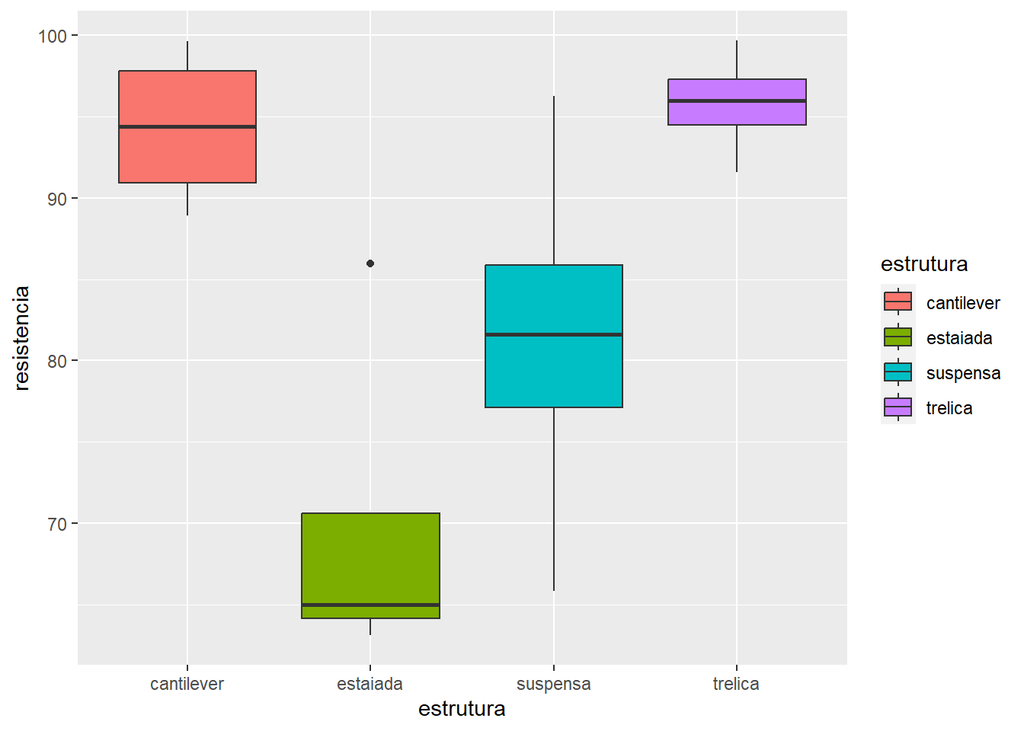

```r
library(ggplot2)
ggplot(dadosEx03, aes(x = estrutura, y = resistencia, fill = estrutura)) + geom_boxplot()
```

- É necessário analisar qual tipo de estrutura é melhor, portanto a análise gráfica é feita **em função das estruturas**. Pela análise gráfica, é possível pressupor que **aparentemente as estruturas mais resistentes são a treliça e a cantiléver**, porém esta **não** deve ser a conclusão final.

##### Análise de variância utilizando o modelo DBC:

```r
library(easyanova)
modeloEx03 = ea1(dadosEx03, design = 2)
```

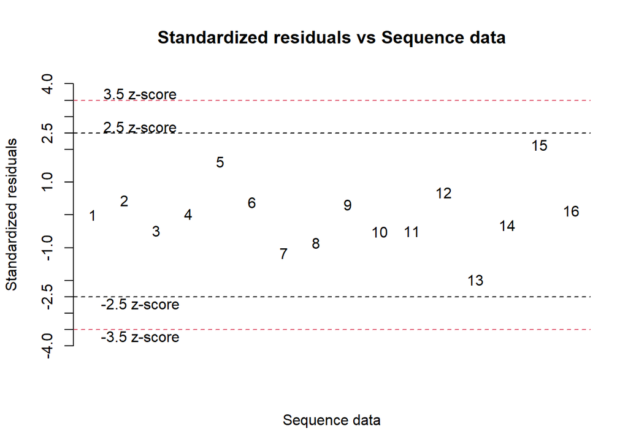

```r
modeloEx03$`Analysis of variance`
```

|  | df | type III SS | mean square | F value | p>F |
| --- | --- | --- | --- | --- | --- |
| treatments | 3 | 1797.1630 | 599.0543 | 6.0435 | 0.0154 |
| blocks | 3 | 31.9097 | 10.6366 | 0.1073 | 0.9537 |
| residuals | 9 | 892.1067 | 99.1230 | - | - |

- Através da análise da tabela acima podemos tirar as seguintes conclusões:
- P-valor = 0.0154, ou seja, **menor** que 0.05 (5%), sendo assim, deve-se **desconsiderar** a hipótese nula (**H0**) citada na questão 2, portanto é válido continuar com a análise.
- Valor F =~ 6, ou seja, > 1, sendo assim, cloclui-se que o efeito do tratamento é de aproximadamente **6 vezes** maior que o efeito dos resíduos.

#### Análise das médias

```r
modeloEx03$`Adjusted means`
```

| treatment | adjusted.mean | standard.error | tukey | snk | duncan | t | scott_knott |
| --- | --- | --- | --- | --- | --- | --- | --- |
| trelica | 95.8081 | 4.978 | a | a | a | a | a |
| cantilever | 94.3311 | 4.978 | a | a | a | a | a |
| suspensa | 81.3387 | 4.978 | ab | ab | ab | ab | b |
| estaiada | 69.7559 | 4.978 | b | b | b | b | b |

- **Conclusão**: Analisando a tabela acima, pode-se concluir que através do teste de **Tukey** as estruturas: **treliça, cantiléver e suspensa**, são **idênticas** com relação a resistência, logo, para escolher qual é a melhor, tem que levar em consderação outros aspectos como preço, viábilidade, etc.